# Table of Contents

**Kernel Author:**  
[Bhishan Poudel, Data Scientist, Ph.D Astrophysics](https://bhishanpdl.github.io/) .

# Data Description

This dataset contains house sale prices for King County, which includes Seattle. It includes homes sold between May 2014 and May 2015.

- Dependent features: 1 (price)
- Features : 19 home features
- Id: 1 house ID

Task: Estimate the price based on given features.

[figure not shown]

## Model Introduction

The term `Boosting` refers to a family of algorithms which converts weak learner to strong learners.

There are many boosting algorithms which impart additional boost to model’s accuracy. In this tutorial, we’ll learn about the two most commonly used algorithms i.e. Gradient Boosting (GBM) and XGboost.

Generally XGboost is considered more advanced than gbm.

- xgboost supports regularization, however gbm does not.
- xgboost is blazingley faster than gbm.
- xgboost has built-in routine to handle missing values.
- xgboost has tree pruning mechanisms,however gbm and random forest are greedy algorithms and do not have tree pruning.
- In xgboost we can run cross-validation at each iteration of the boosting. But in gbm, we have to run grid search.

# Notes

- If we do log transform of target variable `np.log1p`, we need to do the inverse log transform `np.expm1` before model evaluation e.g. rmse, r2 etc

# Imports

```python
import time
time_start_notebook = time.time()
```

```python
import sys
ENV_COLAB = 'google.colab' in sys.modules

if ENV_COLAB:
    !pip install shap # model evaluation

    print('Environment: Google Colab')
```

```python
import numpy as np
import pandas as pd
import seaborn as sns
sns.set(color_codes=True)

import matplotlib
import matplotlib.pyplot as plt
%matplotlib inline

import os
import time

# random state
SEED=100
np.random.seed(SEED) # we need this in each cell

# mixed
import six
import pickle
import joblib
import scipy

# sklearn
import sklearn
from sklearn.preprocessing import StandardScaler
from sklearn.model_selection import train_test_split
from sklearn.pipeline import Pipeline
from sklearn import metrics
from sklearn.metrics import mean_squared_error
from sklearn.metrics import explained_variance_score
from sklearn.model_selection import KFold
from sklearn.model_selection import cross_val_score, cross_val_predict

# classifier
import lightgbm as lgb
from lightgbm import LGBMRegressor

# HPO
from hyperopt import fmin, tpe, hp, STATUS_OK, Trials
from hyperopt.pyll import scope
from hyperopt.pyll.stochastic import sample

# versions
import watermark
%load_ext watermark
%watermark -a "Bhishan Poudel" -d -v -m
print()
%watermark -iv
```

```
Bhishan Poudel 2020-11-02

CPython 3.7.7
IPython 7.18.1

compiler   : Clang 4.0.1 (tags/RELEASE_401/final)
system     : Darwin
release    : 19.6.0
machine    : x86_64
processor  : i386
CPU cores  : 4
interpreter: 64bit

matplotlib 3.2.1
sklearn    0.23.1
numpy      1.18.4
scipy      1.4.1
lightgbm   2.3.1
watermark  2.0.2
six        1.15.0
pandas     1.1.0
joblib     0.17.0
seaborn    0.11.0
```

# Important Scripts

```python
def show_methods(obj, ncols=4,start=None, inside=None):
    """ Show all the attributes of a given method.
    Example:
    ========
    show_method_attributes(list)
     """

    print(f'Object Type: {type(obj)}\n')
    lst = [elem for elem in dir(obj) if elem[0]!='_' ]
    lst = [elem for elem in lst
           if elem not in 'os np pd sys time psycopg2'.split() ]

    if isinstance(start,str):
        lst = [elem for elem in lst if elem.startswith(start)]

    if isinstance(start,tuple) or isinstance(start,list):
        lst = [elem for elem in lst for start_elem in start
               if elem.startswith(start_elem)]

    if isinstance(inside,str):
        lst = [elem for elem in lst if inside in elem]

    if isinstance(inside,tuple) or isinstance(inside,list):
        lst = [elem for elem in lst for inside_elem in inside
               if inside_elem in elem]

    return pd.DataFrame(np.array_split(lst,ncols)).T.fillna('')
```

```python
def adjustedR2(rsquared,nrows,kcols):
    return rsquared- (kcols-1)/(nrows-kcols) * (1-rsquared)
```

# Load the data

```python
df = pd.read_csv('../data/raw/kc_house_data.csv')
print(df.columns)
print(df.shape)
df.head(2)
```

```
Index(['id', 'date', 'price', 'bedrooms', 'bathrooms', 'sqft_living',
       'sqft_lot', 'floors', 'waterfront', 'view', 'condition', 'grade',
       'sqft_above', 'sqft_basement', 'yr_built', 'yr_renovated', 'zipcode',
       'lat', 'long', 'sqft_living15', 'sqft_lot15'],
      dtype='object')
(21613, 21)
```

|  | id | date | price | bedrooms | bathrooms | sqft_living | sqft_lot | floors | waterfront | view | ... | grade | sqft_above | sqft_basement | yr_built | yr_renovated | zipcode | lat | long | sqft_living15 | sqft_lot15 |
| --- | --- | --- | --- | --- | --- | --- | --- | --- | --- | --- | --- | --- | --- | --- | --- | --- | --- | --- | --- | --- | --- |
| 0 | 7129300520 | 20141013T000000 | 221900.0 | 3 | 1.00 | 1180 | 5650 | 1.0 | 0 | 0 | ... | 7 | 1180 | 0 | 1955 | 0 | 98178 | 47.5112 | -122.257 | 1340 | 5650 |
| 1 | 6414100192 | 20141209T000000 | 538000.0 | 3 | 2.25 | 2570 | 7242 | 2.0 | 0 | 0 | ... | 7 | 2170 | 400 | 1951 | 1991 | 98125 | 47.7210 | -122.319 | 1690 | 7639 |

2 rows × 21 columns

# Feature Selection

```python
features_raw_all = ['bedrooms', 'bathrooms', 'sqft_living',
       'sqft_lot', 'floors', 'waterfront', 'view', 'condition', 'grade',
       'sqft_above', 'sqft_basement', 'yr_built', 'yr_renovated', 'zipcode',
       'lat', 'long', 'sqft_living15', 'sqft_lot15']

cols_drop = ['id','date']
df = df.drop(cols_drop,axis=1)


dict_features = dict(enumerate(features_raw_all))
print(dict_features)
```

```
{0: 'bedrooms', 1: 'bathrooms', 2: 'sqft_living', 3: 'sqft_lot', 4: 'floors', 5: 'waterfront', 6: 'view', 7: 'condition', 8: 'grade', 9: 'sqft_above', 10: 'sqft_basement', 11: 'yr_built', 12: 'yr_renovated', 13: 'zipcode', 14: 'lat', 15: 'long', 16: 'sqft_living15', 17: 'sqft_lot15'}
```

# Log transform large values

```python
cols_log = ['price','sqft_living','sqft_living15','sqft_lot','sqft_lot15']

df = df.copy()
for col in cols_log:
    df[col] = np.log1p(df[col].to_numpy())
```

# Train-Test split after log transform

```python
X = df[features_raw_all].to_numpy()

y = df['price'].to_numpy()

Xtrain, Xtest, ytrain, ytest = train_test_split (X,y,test_size=0.20,
                                                 random_state=SEED)

Xtrain.shape, ytrain.shape, Xtest.shape, ytest.shape, Xtrain[0][:2], Xtest[0][:2]
```

```
((17290, 18),
 (17290,),
 (4323, 18),
 (4323,),
 array([3.  , 1.75]),
 array([3. , 2.5]))
```

# Train-Validation Split

```python
# train validation split
Xtrain, Xvalid, ytrain, yvalid = train_test_split(
    Xtrain, ytrain, test_size=0.2, random_state=SEED)

Xtrain.shape, Xtest.shape, Xvalid.shape
```

```
((13832, 18), (4323, 18), (3458, 18))
```

# Scaling the Data

```python
from sklearn.preprocessing import StandardScaler

scaler = StandardScaler()
scaler.fit(Xtrain)

Xtrain_scaled = scaler.transform(Xtrain)
Xtest_scaled = scaler.transform(Xtest)
Xvalid_scaled = scaler.transform(Xvalid)

Xtrain_scaled[0][:2], Xtest_scaled[0][:2]
```

```
(array([1.73814209, 1.166196  ]), array([-0.38121452,  0.51397123]))
```

```python
df_Xtrain_scaled = pd.DataFrame(Xtrain_scaled, columns=features_raw_all)
df_Xvalid_scaled = pd.DataFrame(Xvalid_scaled, columns=features_raw_all)
df_Xtest_scaled = pd.DataFrame(Xtest_scaled, columns=features_raw_all)
```

# Modelling lightgbm

References:

- [LightGBM Parameters](https://lightgbm.readthedocs.io/en/latest/Parameters.html)
- [LightGBM Parameters Tuning](https://lightgbm.readthedocs.io/en/latest/Parameters-Tuning.html)
- [analytics vidhya: Which algorithm takes the crown: Light GBM vs XGBOOST?](https://www.analyticsvidhya.com/blog/2017/06/which-algorithm-takes-the-crown-light-gbm-vs-xgboost/)
- [lightgbm plotting official](https://github.com/microsoft/LightGBM/blob/master/examples/python-guide/plot_example.py)

**Light GBM**

This is based on decision tree and it splits the tree leaf with best fit instead of splitting the level-wise (depth-wise).

[figure not shown]

- **Fast**: Light GBM is fast as light, it is much faster than other boosting algorithms such as AdaBoost and XGboost.
- **Low Memory**: It uses lower memory than other boosting algorithms since it uses discrete bins instead of continuous variables.
- **Better Accuracy**: It gives better accuracy then other boosting algorithms. However, as for all other machine learning techniques it needs hyperparamter tuning.
- **Scaling for large data**: Since this algorithm is lighting fast we can use this algorithm for large datasets.
- **Parallelism Supported**: Boosting algoriths are generally sequential. They need to boost the weak learner in each iteration. But this implementation uses some clever tricks to use parallel processing.
- **GPU Support**: This algorithm also support gpu for faster training.

```python
import lightgbm as lgb

show_methods(lgb)
```

```
Object Type: <class 'module'>
```

|  | 0 | 1 | 2 | 3 |
| --- | --- | --- | --- | --- |
| 0 | Booster | basic | engine | print_evaluation |
| 1 | Dataset | callback | libpath | record_evaluation |
| 2 | LGBMClassifier | compat | plot_importance | reset_parameter |
| 3 | LGBMModel | create_tree_digraph | plot_metric | sklearn |
| 4 | LGBMRanker | cv | plot_split_value_histogram | train |
| 5 | LGBMRegressor | dir_path | plot_tree | version_file |
| 6 | absolute_import | early_stopping | plotting |  |

```python
import lightgbm as lgb
from lightgbm import LGBMRegressor
from sklearn.model_selection import KFold
from sklearn.model_selection import cross_val_score, cross_val_predict


# model fit
model_lgb = LGBMRegressor(n_jobs=-1, random_state=SEED)

model_lgb
```

```
LGBMRegressor(random_state=100)
```

```python
# model fit
model_lgb = LGBMRegressor(n_jobs=-1, random_state=SEED)
model_lgb.fit(Xtrain_scaled, ytrain)

# cross validation score
kf = KFold(n_splits=5,shuffle=True,random_state=SEED)
scores = cross_val_score(model_lgb, Xtrain_scaled, ytrain, cv=kf,
                         scoring = "neg_mean_squared_error")
# sklearn.metrics.SCORERS.keys()
train_neg_mse = scores.mean()
print('Train Negative MSE CV: ', train_neg_mse)

# save the model
# joblib.dump(model_lgb, 'model_lgb.pkl')
# model_lgb = joblib.load('model_xgb.pkl')

# predictions
ypreds = model_lgb.predict(Xtest_scaled)

# NOTE: if we have log1p transform the target, we need to get it back
ytest_back = np.expm1(ytest)
ypreds_back = np.expm1(ypreds)

# rmse
rmse = np.sqrt(sklearn.metrics.mean_squared_error(ytest_back,ypreds_back))
print(f'Test RMSE: {rmse}')

# explained variance score
evs = explained_variance_score(ypreds_back, ytest_back)
print('Explained Variance Score: ', evs)

# r-squared values
r2 = sklearn.metrics.r2_score(ytest_back, ypreds_back)
ar2 = adjustedR2(r2, Xtest_scaled.shape[0], Xtest_scaled.shape[1])
print('r_squared: ', r2)
print('adjustedr2: ', ar2)
```

```
Train Negative MSE CV:  -0.028574683314057103
Test RMSE: 120963.87097082644
Explained Variance Score:  0.8610591188627416
r_squared:  0.8914272059588215
adjustedr2:  0.8909984632181247
```

```python
show_methods(model_lgb)
```

```
Object Type: <class 'lightgbm.sklearn.LGBMRegressor'>
```

|  | 0 | 1 | 2 | 3 |
| --- | --- | --- | --- | --- |
| 0 | best_iteration_ | fit | n_estimators | reg_alpha |
| 1 | best_score_ | get_params | n_features_ | reg_lambda |
| 2 | booster_ | importance_type | n_jobs | score |
| 3 | boosting_type | learning_rate | num_leaves | set_params |
| 4 | class_weight | max_depth | objective | silent |
| 5 | colsample_bytree | min_child_samples | objective_ | subsample |
| 6 | evals_result_ | min_child_weight | predict | subsample_for_bin |
| 7 | feature_importances_ | min_split_gain | random_state | subsample_freq |

```python
# feature importance
df_imp = pd.DataFrame({'Feature': features_raw_all,
                       'Importance': model_lgb.feature_importances_
                       })

df_imp.sort_values('Importance',ascending=False).style.background_gradient()
```

|  | Feature | Importance |
| --- | --- | --- |
| 14 | lat | 521 |
| 15 | long | 450 |
| 11 | yr_built | 266 |
| 3 | sqft_lot | 255 |
| 2 | sqft_living | 248 |
| 13 | zipcode | 190 |
| 16 | sqft_living15 | 179 |
| 17 | sqft_lot15 | 154 |
| 9 | sqft_above | 141 |
| 8 | grade | 119 |
| 7 | condition | 108 |
| 6 | view | 85 |
| 10 | sqft_basement | 77 |
| 1 | bathrooms | 62 |
| 12 | yr_renovated | 48 |
| 5 | waterfront | 42 |
| 0 | bedrooms | 37 |
| 4 | floors | 18 |

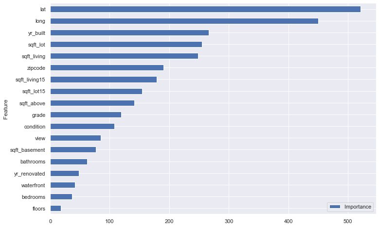

```python
df_imp.sort_values('Importance').set_index('Feature').sort_values('Importance').plot.barh(figsize=(12,8))
```

```
['bedrooms', 'bathrooms', 'sqft_living', 'sqft_lot', 'floors', 'waterfront', 'view', 'condition', 'grade', 'sqft_above', 'sqft_basement', 'yr_built', 'yr_renovated', 'zipcode', 'lat', 'long', 'sqft_living15', 'sqft_lot15']
{0: 'bedrooms', 1: 'bathrooms', 2: 'sqft_living', 3: 'sqft_lot', 4: 'floors', 5: 'waterfront', 6: 'view', 7: 'condition', 8: 'grade', 9: 'sqft_above', 10: 'sqft_basement', 11: 'yr_built', 12: 'yr_renovated', 13: 'zipcode', 14: 'lat', 15: 'long', 16: 'sqft_living15', 17: 'sqft_lot15'}
```

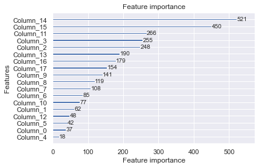

```python
axsub = lgb.plot_importance(model_lgb)
print(features_raw_all)
print(dict_features)
```

```
{0: 'bedrooms', 1: 'bathrooms', 2: 'sqft_living', 3: 'sqft_lot', 4: 'floors', 5: 'waterfront', 6: 'view', 7: 'condition', 8: 'grade', 9: 'sqft_above', 10: 'sqft_basement', 11: 'yr_built', 12: 'yr_renovated', 13: 'zipcode', 14: 'lat', 15: 'long', 16: 'sqft_living15', 17: 'sqft_lot15'}
```

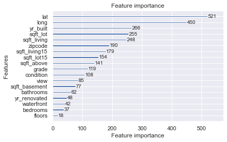

```python
axsub = lgb.plot_importance(model_lgb)

Text_yticklabels = list(axsub.get_yticklabels())
dict_features = dict(enumerate(features_raw_all))
lst_yticklabels = [ Text_yticklabels[i].get_text().lstrip('Column_') for i in range(len(Text_yticklabels))]
lst_yticklabels = [ dict_features[int(i)] for i in lst_yticklabels]

axsub.set_yticklabels(lst_yticklabels)
print(dict_features)
plt.show()
```

# LightGBM using Dataset (Memory Reducing data container)

```python
categorical_feature = ['view','grade']
dtrain = lgb.Dataset(Xtrain_scaled,ytrain,
                     free_raw_data=False,
                     feature_name=features_raw_all,
                     categorical_feature=categorical_feature
                     )

dvalid = lgb.Dataset(Xvalid_scaled,yvalid,
                     free_raw_data=False,
                     feature_name=features_raw_all,
                     categorical_feature=categorical_feature
                     )
type(dtrain)
```

```
lightgbm.basic.Dataset
```

```python
# params
params = {
    'objective' : 'regression', # regression binary etc
    'metric' : ['l1','l2','rmse','mape'],
    'num_leaves' : 200,
    'max_depth': 15,
    'learning_rate' : 0.01,
    'feature_fraction' : 0.6,
    'verbosity' : -1
}
num_boost_round = 500_000
evals_result = {}  # to record eval results for plotting
model_lgb = lgb.train(params,dtrain,num_boost_round=num_boost_round,
    valid_sets=[dtrain, dvalid],
    valid_names=["train", "valid"],
    evals_result=evals_result,
    early_stopping_rounds=500, # choose num_boost_round much larger than this
    verbose_eval=500 # print every nth interval
)

# test the model
ypreds = model_lgb.predict(Xtest_scaled)


# NOTE: if we have log1p transform the target, we need to get it back
ytest_back = np.expm1(ytest)
ypreds_back = np.expm1(ypreds)

# rmse
rmse = np.sqrt(sklearn.metrics.mean_squared_error(ytest_back,ypreds_back))
print(f'Test RMSE: {rmse}')

# explained variance score
evs = explained_variance_score(ypreds_back, ytest_back)
print('Explained Variance Score: ', evs)

# r-squared values
r2 = sklearn.metrics.r2_score(ytest_back, ypreds_back)
ar2 = adjustedR2(r2, Xtest_scaled.shape[0], Xtest_scaled.shape[1])
print('r_squared: ', r2)
print('adjustedr2: ', ar2)
```

```
Training until validation scores don't improve for 500 rounds
[500]	train's l1: 0.0826967	train's l2: 0.0131812	train's rmse: 0.11481	train's mape: 0.00637857	valid's l1: 0.118464	valid's l2: 0.0279617	valid's rmse: 0.167218	valid's mape: 0.00908907
[1000]	train's l1: 0.0651797	train's l2: 0.00826552	train's rmse: 0.0909149	train's mape: 0.00503483	valid's l1: 0.11601	valid's l2: 0.0271574	valid's rmse: 0.164795	valid's mape: 0.00890542
[1500]	train's l1: 0.0551864	train's l2: 0.006059	train's rmse: 0.0778396	train's mape: 0.00426551	valid's l1: 0.115984	valid's l2: 0.0272387	valid's rmse: 0.165041	valid's mape: 0.00890503
Early stopping, best iteration is:
[1022]	train's l1: 0.0646142	train's l2: 0.00812941	train's rmse: 0.0901632	train's mape: 0.00499123	valid's l1: 0.115983	valid's l2: 0.0271457	valid's rmse: 0.164759	valid's mape: 0.00890354
Test RMSE: 119775.26607402352
Explained Variance Score:  0.866042566322356
r_squared:  0.8935504204823237
adjustedr2:  0.8931300620963073
```

```python
pd.DataFrame(evals_result).head()
```

|  | train | valid |
| --- | --- | --- |
| l1 | [0.409860345025214, 0.4067494715094026, 0.4033... | [0.40779839360684583, 0.40476967607466874, 0.4... |
| l2 | [0.2724803673441301, 0.2683572992890676, 0.264... | [0.27276060113405676, 0.2686722404331257, 0.26... |
| rmse | [0.521996520432972, 0.5180321411737573, 0.5138... | [0.5222648764123974, 0.5183360304215072, 0.514... |
| mape | [0.03137379051376919, 0.03113595519025722, 0.0... | [0.031104541089476183, 0.030873935990280668, 0... |

```
Plotting metrics recorded during training...
```

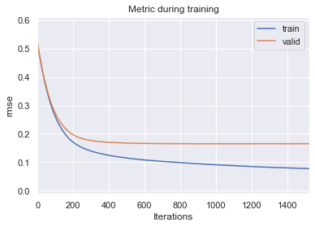

```python
print('Plotting metrics recorded during training...')
ax = lgb.plot_metric(evals_result, metric='rmse')
plt.show()
```

```
Plotting metrics recorded during training...
```

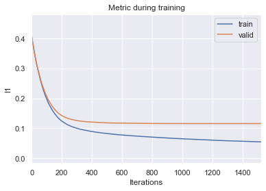

```python
print('Plotting metrics recorded during training...')
ax = lgb.plot_metric(evals_result, metric='l1')
plt.show()
```

```
Plotting feature importances...
```

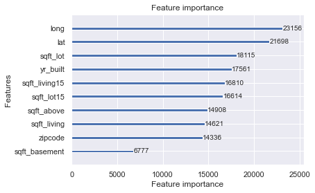

```python
print('Plotting feature importances...')
ax = lgb.plot_importance(model_lgb, max_num_features=10)
plt.show()
```

```python
# print('Plotting 54th tree...')  # one tree use categorical feature to split
# ax = lgb.plot_tree(model_lgb, tree_index=53, figsize=(15, 15), show_info=['split_gain'])
# plt.show()
```

```python
# print('Plotting 54th tree with graphviz...')
# graph = lgb.create_tree_digraph(model_lgb, tree_index=53, name='Tree54')
# graph.render(view=False
```

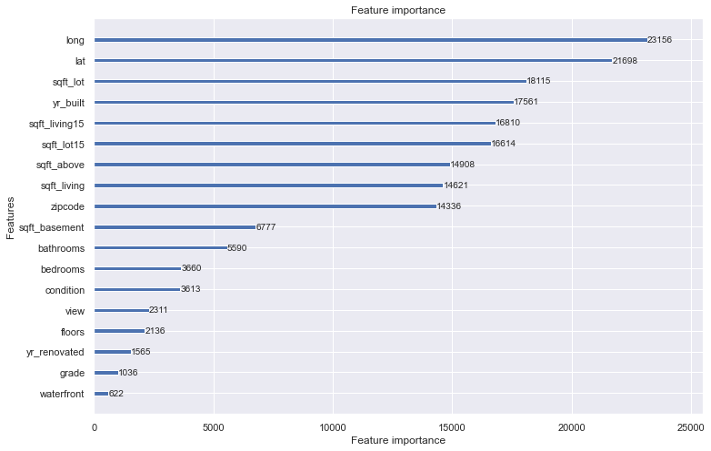

```python
lgb.plot_importance(model_lgb,figsize=(12,8))
```

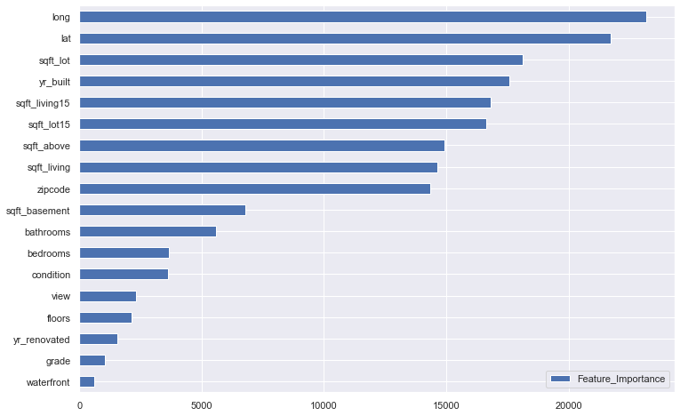

```python
fe = model_lgb.feature_importance()

df_imp = pd.DataFrame(fe, index=features_raw_all,columns=['Feature_Importance'])

df_imp.sort_values('Feature_Importance').plot.barh(figsize=(12,8))
```

```python
# lgb.plot_tree(model_lgb, figsize=(20,20))
```

# Cross Validation

```python
# # params
# params_small = {'num_leaves':300,
#           'objective':'regression', # use binary for classification
#           'max_depth':7,
#           'learning_rate':.05,
#           'max_bin':200,
#           'min_data_in_leaf': 10,
#           'random_state': RANDOM_STATE,
#           'metric': ['rmse', 'mae','mape','auc']
#           }


# num_boost_round = 10_000
# n_folds = 5
# cv_results = lgb.cv(params_small,
#                     dtrain,
#                     num_boost_round=num_boost_round,
#                     nfold = n_folds,
#                     early_stopping_rounds = 100,
#                     metrics = 'rmse',
#                     seed = RANDOM_STATE)


# ValueError: Supported target types are: ('binary', 'multiclass'). Got 'continuous' instead.
```

# Model Evaluation of lightgbm using Shap

References:

- https://www.kaggle.com/cast42/lightgbm-model-explained-by-shap
- https://www.kaggle.com/wrosinski/shap-feature-importance-with-feature-engineering

```python
import shap
```

```python
show_methods(shap)
```

```
Object Type: <class 'module'>
```

|  | 0 | 1 | 2 | 3 |
| --- | --- | --- | --- | --- |
| 0 | AdditiveExplainer | Tree | force_plot | partial_dependence_plot |
| 1 | BruteForceExplainer | TreeExplainer | have_matplotlib | partition_tree |
| 2 | DeepExplainer | approximate_interactions | hclust_ordering | plots |
| 3 | GradientExplainer | bar_plot | image_plot | sample |
| 4 | ImageMasker | common | initjs | save_html |
| 5 | KernelExplainer | datasets | kmeans | summary_plot |
| 6 | LinearExplainer | decision_plot | matplotlib | text_plot |
| 7 | PartitionExplainer | dependence_plot | monitoring_plot | unsupported |
| 8 | PermutationExplainer | embedding_plot | multioutput_decision_plot | warnings |
| 9 | SamplingExplainer | explainers | other | waterfall_plot |
| 10 | TokenMasker |  |  |  |

```python
%time shap_values = shap.TreeExplainer(model_lgb).shap_values(df_Xvalid_scaled)
```

```
Setting feature_perturbation = "tree_path_dependent" because no background data was given.
```

```
CPU times: user 3min 39s, sys: 851 ms, total: 3min 39s
Wall time: 1min 26s
```

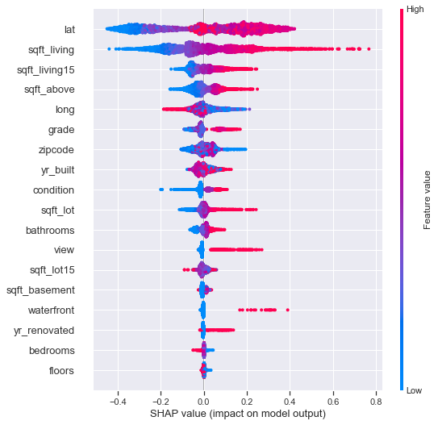

```python
shap.summary_plot(shap_values, df_Xvalid_scaled)
```

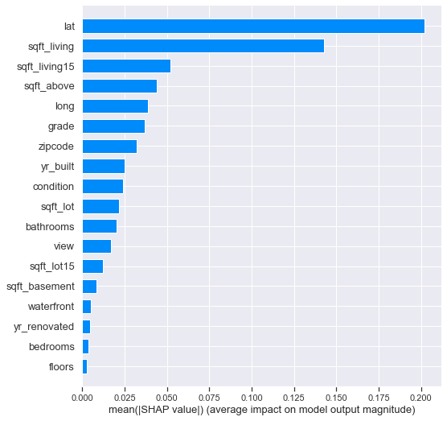

```python
shap.summary_plot(shap_values, df_Xvalid_scaled, plot_type='bar')
```

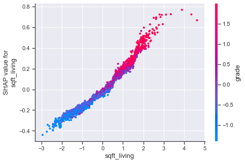

```python
shap.dependence_plot("sqft_living", shap_values, df_Xvalid_scaled)
```

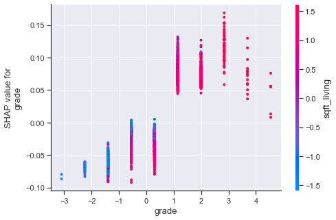

```python
shap.dependence_plot("grade", shap_values, df_Xvalid_scaled)
```

# HPO (Hyper Parameter Optimization)

Parameters:

- learning_rate: step size shrinkage used to prevent overfitting. Range is [0,1]
- max_depth: determines how deeply each tree is allowed to grow during any boosting round.
- subsample: percentage of samples used per tree. Low value can lead to underfitting.
- colsample_bytree: percentage of features used per tree. High value can lead to overfitting.
- n_estimators: number of trees you want to build.

Regularization parameters:

- gamma: controls whether a given node will split based on the expected reduction in loss after the split. A higher value leads to fewer splits. Supported only for tree-based learners.
- alpha: L1 regularization on leaf weights. A large value leads to more regularization.
- lambda: L2 regularization on leaf weights and is smoother than L1 regularization.

```python
from hyperopt import fmin, tpe, hp, STATUS_OK, Trials
from hyperopt.pyll import scope
from hyperopt.pyll.stochastic import sample
```

```python
import time
from sklearn.model_selection import GridSearchCV, RandomizedSearchCV
from sklearn.model_selection import cross_val_score

def hpo_search(pipe, params, Xtrain, ytrain, Xtest, ytest,
           optimizer='grid_search', n_iter=None,cv=3,
           scoring='neg_mean_squared_error'):

    """Hyper Parameter Optimazation using Grid Search and Random Search.

    Returns:
    - df_results : Pandas Dataframe of results
    - best_estimator: Best estimator found
    """

    time_start = time.time()

    if optimizer == 'grid_search':
        grid_obj = GridSearchCV(estimator=pipe,
                                param_grid=params,
                                cv=cv,
                                refit=True,
                                n_jobs=-1,
                                return_train_score=False,
                                scoring=scoring,
                               )
        grid_obj.fit(Xtrain, ytrain,)

    elif optimizer == 'random_search':
        grid_obj = RandomizedSearchCV(estimator=pipe,
                            param_distributions=params,
                            cv=cv,
                            n_iter=n_iter,
                            refit=True,
                            n_jobs=-1,
                            return_train_score=False,
                            scoring=scoring,
                            random_state=SEED)
        grid_obj.fit(Xtrain, ytrain,)

    else:
        print('enter search method')
        return

    best_estimator = grid_obj.best_estimator_
    cvs = cross_val_score(best_estimator, Xtrain, ytrain, cv=cv)

    df_results = pd.DataFrame(grid_obj.cv_results_)

    time_taken = time.time() - time_start
    print("\nResults\n" + '='*50)
    print('Time taken: {:.0f} min {:.0f} secs'.format(*divmod(time_taken,60)))
    print("Number of parameter combinations tested: ", df_results.shape[0])
    print("Cross-validation Score                 : {:.4f}".format(cvs.mean()))
    print("Train Score Best                       : {:.4f} ".format(grid_obj.best_score_))
    print("Test Score                             : {:.4f} ".format(best_estimator.score(Xtest, ytest)))
    print("Best parameters: ", grid_obj.best_params_)

    return df_results, best_estimator
```

```python
pipe = Pipeline([
    ('clf', lgb.LGBMRegressor(seed=SEED))
    ])

param_gridsearch = {
    'clf__learning_rate' : [0.01, 0.1, 1],
    'clf__max_depth' : [5, 10, 15],
    'clf__n_estimators' : [100, 200, 500],
    'clf__num_leaves' : [5, 25, 50],
    'clf__boosting_type': ['gbdt', 'dart'],
    'clf__colsample_bytree' : [0.6, 0.75, 1],
    'clf__reg_lambda': [0.01, 0.1, 1],
}

param_random = {
    'clf__learning_rate': list(np.logspace(np.log(0.01), np.log(1), num = 500, base=3)),
    'clf__max_depth': list(range(5, 15)),
    'clf__n_estimators': list(range(100, 500,50)),
    'clf__num_leaves': list(range(5, 50)),
    'clf__boosting_type': ['gbdt', 'dart'],
    'clf__colsample_bytree': list(np.linspace(0.6, 1, 500)),
    'clf__reg_lambda': list(np.linspace(0, 1, 500)),
}

param_hyperopt= {
    'learning_rate': hp.loguniform('learning_rate', np.log(0.01), np.log(1)),
    'max_depth': scope.int(hp.quniform('max_depth', 5, 15, 1)),
    'n_estimators': scope.int(hp.quniform('n_estimators', 100, 500, 50)),
    'num_leaves': scope.int(hp.quniform('num_leaves', 5, 50, 1)),
    'boosting_type': hp.choice('boosting_type', ['gbdt', 'dart']),
    'colsample_bytree': hp.uniform('colsample_by_tree', 0.6, 1.0),
    'reg_lambda': hp.uniform('reg_lambda', 0.0, 1.0),
}
```

```python
#results_grid, estimator_grid = search(pipe, param_gridsearch,
#  Xtrain_scaled, ytrain, Xtest_scaled, ytest, 'grid_search')
```

```python
num_eval = 5 # 100 # keep this same for random search and grid search for plotting purpose
```

```python
pipe = Pipeline([
    ('clf', lgb.LGBMRegressor(seed=SEED))
    ])


param_random = {
    'clf__learning_rate': list(np.logspace(np.log(0.01), np.log(1), num = 500, base=3)),
    'clf__max_depth': list(range(5, 15)),
    'clf__n_estimators': list(range(100, 500,50)),
    'clf__num_leaves': list(range(5, 50)),
    'clf__boosting_type': ['gbdt', 'dart'],
    'clf__colsample_bytree': list(np.linspace(0.6, 1, 500)),
    'clf__reg_lambda': list(np.linspace(0, 1, 500)),
}
results_random, estimator_random = hpo_search(pipe, param_random,
                                          Xtrain_scaled, ytrain,
                                          Xtest_scaled, ytest,
                                          'random_search', num_eval)
```

```
Results
==================================================
Time taken: 0 min 14 secs
Number of parameter combinations tested:  5
Cross-validation Score                 : 0.8987
Train Score Best                       : -0.0280
Test Score                             : 0.9090
Best parameters:  {'clf__reg_lambda': 0.7615230460921844, 'clf__num_leaves': 34, 'clf__n_estimators': 400, 'clf__max_depth': 6, 'clf__learning_rate': 0.043590715660486466, 'clf__colsample_bytree': 0.6328657314629258, 'clf__boosting_type': 'gbdt'}
```

## HPO Using hyperopt

```python
def hpo_hyperopt(param_space, Xtrain, ytrain, Xtest, ytest, num_eval,cv=3):

    time_start = time.time()

    def objective_function(params):
        model = lgb.LGBMRegressor(**params)
        score = cross_val_score(model, Xtrain, ytrain, cv=cv).mean()
        return {'loss': -score, 'status': STATUS_OK}

    trials = Trials()
    best_param = fmin(objective_function,
                      param_space,
                      algo=tpe.suggest,
                      max_evals=num_eval,
                      trials=trials,
                      rstate= np.random.RandomState(SEED))
    loss = [x['result']['loss'] for x in trials.trials]

    best_param_values = [x for x in best_param.values()]

    if best_param_values[0] == 0:
        boosting_type = 'gbdt'
    else:
        boosting_type= 'dart'

    model_best = lgb.LGBMRegressor(learning_rate=best_param_values[2],
                                  num_leaves=int(best_param_values[5]),
                                  max_depth=int(best_param_values[3]),
                                  n_estimators=int(best_param_values[4]),
                                  boosting_type=boosting_type,
                                  colsample_bytree=best_param_values[1],
                                  reg_lambda=best_param_values[6],
                                 )

    model_best.fit(Xtrain, ytrain)

    time_taken = time.time() - time_start

    print("\nResults\n" + '='*50)
    print('Time taken: {:.0f} min {:.0f} secs'.format(*divmod(time_taken,60)))
    print("Number of parameter combinations tested: ", num_eval)
    print("Train Score Best                       : {:.4f} ".format(min(loss)*-1))
    print("Test Score                             : {:.4f} ".format(model_best.score(Xtest, ytest)))
    print("Best parameters: ", best_param)

    return trials
```

```python
# num_eval = same as above # keep it same as random search for further plots
param_hyperopt= {
    'learning_rate': hp.loguniform('learning_rate', np.log(0.01), np.log(1)),
    'max_depth': scope.int(hp.quniform('max_depth', 5, 15, 1)),
    'n_estimators': scope.int(hp.quniform('n_estimators', 100, 500, 50)),
    'num_leaves': scope.int(hp.quniform('num_leaves', 5, 50, 1)),
    'boosting_type': hp.choice('boosting_type', ['gbdt', 'dart']),
    'colsample_bytree': hp.uniform('colsample_by_tree', 0.6, 1.0),
    'reg_lambda': hp.uniform('reg_lambda', 0.0, 1.0),
}


results_hyperopt = hpo_hyperopt(param_hyperopt, Xtrain_scaled, ytrain,
                                Xtest_scaled, ytest, num_eval)
```

```
Results
==================================================
Time taken: 0 min 47 secs
Number of parameter combinations tested:  5
Train Score Best                       : 0.8949
Test Score                             : 0.9059
Best parameters:  {'boosting_type': 1, 'colsample_by_tree': 0.6827217291517615, 'learning_rate': 0.7194682220148156, 'max_depth': 6.0, 'n_estimators': 250.0, 'num_leaves': 13.0, 'reg_lambda': 0.46481057341908916}
```

```python
# Retrieve Hyperopt scores
hyperopt_scores = [trial['result']['loss']*-1 for trial in results_hyperopt.trials]
hyperopt_scores = np.maximum.accumulate(hyperopt_scores)

# Retrieve Random Search scores
random_scores = np.maximum.accumulate(results_random['mean_test_score'])
```

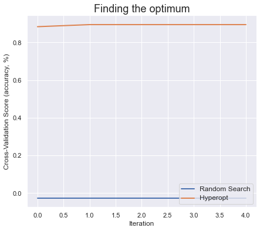

```python
# Plot evaluation scores of each method over time

f, ax = plt.subplots(figsize=(7,6))
sns.set_palette("husl")
sns.despine()
ax = sns.lineplot(x=[x for x in range(num_eval)], y=random_scores, linewidth = 2)
ax = sns.lineplot(x=[x for x in range(num_eval)], y=hyperopt_scores, linewidth = 2)
plt.title("Finding the optimum", fontsize=18)
plt.xlabel('Iteration', fontsize=12)
plt.ylabel('Cross-Validation Score (accuracy, %)', fontsize=12)
plt.legend(loc='lower right', labels=['Random Search', 'Hyperopt'])
plt.setp(ax.get_legend().get_texts(), fontsize='12')
plt.show()
```

## Plot learning rate & num_leaves sampling distribution vs. distribution of values sampled by Hyperopt

```python
# Randomly sample from learning rate and num_leaves distribution

learning_rate_space = {'learning_rate':
                       hp.loguniform('learning_rate', np.log(0.01), np.log(1))}

num_leaves_space = {'num_leaves':
                    scope.int(hp.quniform('num_leaves', 5, 50, 1))}

learning_rate_dist = [sample(learning_rate_space)['learning_rate']
                      for x in range(1000)]

num_leaves_dist = [sample(num_leaves_space)['num_leaves']
                   for x in range(1000)]
```

```python
# Retrieve learning rates and num_leaves' used by Hyperopt

learning_rate_hp = [trial['misc']['vals']['learning_rate'][0] for trial in results_hyperopt.trials]
num_leaves_hp = [trial['misc']['vals']['num_leaves'][0] for trial in results_hyperopt.trials]
```

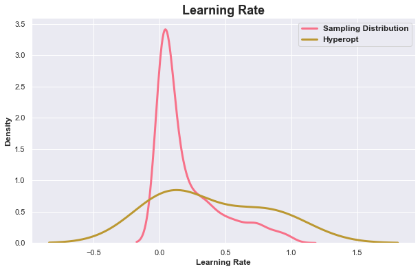

```python
# Plot learning rate sampling distribution vs. values used by Hyperopt

f, ax = plt.subplots(figsize=(10,6))
sns.set_palette("husl")
sns.despine()
ax = sns.kdeplot(learning_rate_dist, label = 'Sampling Distribution', linewidth = 3)
ax = sns.kdeplot(learning_rate_hp, label = 'Hyperopt', linewidth = 3)
plt.title("Learning Rate", fontsize=18, fontweight='bold')
plt.xlabel('Learning Rate', fontsize=12, fontweight='bold')
plt.ylabel('Density', fontsize=12, fontweight='bold');
plt.legend()
plt.setp(ax.get_legend().get_texts(), fontsize='12', fontweight='bold')
plt.show()
```

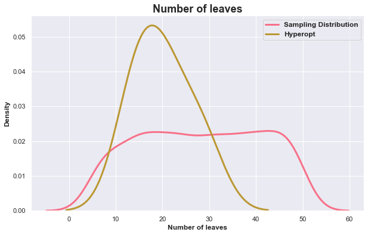

```python
# Plot num_leaves sampling distribution vs. values used by Hyperopt

f, ax = plt.subplots(figsize=(10,6))
sns.set_palette("husl")
sns.despine()
ax = sns.kdeplot(num_leaves_dist, label = 'Sampling Distribution', linewidth = 3)
ax = sns.kdeplot(num_leaves_hp, label = 'Hyperopt', linewidth = 3)
plt.title("Number of leaves", fontsize=18, fontweight='bold')
plt.xlabel('Number of leaves', fontsize=12, fontweight='bold')
plt.ylabel('Density', fontsize=12, fontweight='bold')
plt.legend()
plt.setp(ax.get_legend().get_texts(), fontsize='12', fontweight='bold')
plt.show()
```

# Best Model

```python
# baseline model
LGBMRegressor(n_jobs=-1, random_state=SEED)
```

```
LGBMRegressor(random_state=100)
```

```python
# model fit
model_lgb = LGBMRegressor(n_jobs=-1, random_state=SEED)
model_lgb.fit(Xtrain_scaled, ytrain)

# cross validation score
kf = KFold(n_splits=5,shuffle=True,random_state=SEED)
scores = cross_val_score(model_lgb, Xtrain_scaled, ytrain, cv=kf,
                         scoring = "neg_mean_squared_error")
# sklearn.metrics.SCORERS.keys()
train_neg_mse = scores.mean()
print('Train Negative MSE CV: {:.4f}'.format(train_neg_mse))

# save the model
# joblib.dump(model_lgb, 'model_lgb.pkl')
# model_lgb = joblib.load('model_xgb.pkl')

# predictions
ypreds = model_lgb.predict(Xtest_scaled)

# rmse
rmse = np.sqrt(sklearn.metrics.mean_squared_error(ytest,ypreds))
print(f'Test RMSE: {rmse:.4f}')

# explained variance score
evs = explained_variance_score(ypreds, ytest)
print('Explained Variance Score: {:.4f}'.format( evs))

# r-squared values
r2 = sklearn.metrics.r2_score(ytest, ypreds)
ar2 = adjustedR2(r2, Xtest_scaled.shape[0], Xtest_scaled.shape[1])
print('r_squared : {:.4f}'.format(r2))
print('adjustedr2: {:.4f}'.format(ar2))
```

```
Train Negative MSE CV: -0.0286
Test RMSE: 0.1633
Explained Variance Score: 0.8919
r_squared : 0.9049
adjustedr2: 0.9045
```

```python
# the result of best param
# clean this result and use it.
best_parameters:  {'boosting_type': 0, # 0 means 'gbdt'
                   'colsample_by_tree': 0.6924450244000107,
                   'learning_rate': 0.026476268132746204,
                   'max_depth': 10.0,
                   'n_estimators': 400.0,  # make integer
                   'num_leaves': 46.0,  # make integer
                   'reg_lambda': 0.44732535692405184}
```

```python
# best params so far
best_params = {'boosting_type': 'gbdt', # 0 means gbdt in this case
               'colsample_by_tree': 0.692,
               'learning_rate': 0.026,
               'max_depth': 10,
               'n_estimators': 400,
               'num_leaves': 46,
               'reg_lambda': 0.447}
# model fit
model_lgb = LGBMRegressor(n_jobs=-1, random_state=SEED, **best_params)
model_lgb.fit(Xtrain_scaled, ytrain)

# cross validation score
kf = KFold(n_splits=5,shuffle=True,random_state=SEED)
scores = cross_val_score(model_lgb, Xtrain_scaled, ytrain, cv=kf, scoring = "neg_mean_squared_error")
# sklearn.metrics.SCORERS.keys()
train_neg_mse = scores.mean()
print('Train Negative MSE CV: {:.4f}'.format(train_neg_mse))

# save the model
# joblib.dump(model_lgb, 'model_lgb.pkl')
# model_lgb = joblib.load('model_xgb.pkl')

# predictions
ypreds = model_lgb.predict(Xtest_scaled)

# NOTE: if we have log1p transform the target, we need to get it back
ytest_back = np.expm1(ytest)
ypreds_back = np.expm1(ypreds)

# rmse
rmse = np.sqrt(sklearn.metrics.mean_squared_error(ytest_back,ypreds_back))
print(f'Test RMSE: {rmse}')

# explained variance score
evs = explained_variance_score(ypreds_back, ytest_back)
print('Explained Variance Score: ', evs)

# r-squared values
r2 = sklearn.metrics.r2_score(ytest_back, ypreds_back)
ar2 = adjustedR2(r2, Xtest_scaled.shape[0], Xtest_scaled.shape[1])
print('r_squared: ', r2)
print('adjustedr2: ', ar2)
```

```
Train Negative MSE CV: -0.0280
Test RMSE: 120510.7733064396
Explained Variance Score:  0.8646530232406522
r_squared:  0.8922390507716693
adjustedr2:  0.8918135139222194
```

```python
# adjusted r-squared increased little bit.
# default: 0.8914 (100 esitmators)
# to     : 0.8922 (400 estimators)

# this is still less than xgboost result with 400 estimators.
# where I got 0.90
```

```python
# n_estimators found in max, i need to increase this
# also take more evals.
```

```python
num_eval = 10 # 500 # now we can increate this for hpo
param_hyperopt= {
    'learning_rate': hp.loguniform('learning_rate', np.log(0.01), np.log(1)),
    'max_depth': scope.int(hp.quniform('max_depth', 5, 15, 1)),
    'n_estimators': scope.int(hp.quniform('n_estimators', 400, 900, 50)),
    'num_leaves': scope.int(hp.quniform('num_leaves', 5, 50, 1)),
    'boosting_type': hp.choice('boosting_type', ['gbdt', 'dart']),
    'colsample_bytree': hp.uniform('colsample_by_tree', 0.6, 1.0),
    'reg_lambda': hp.uniform('reg_lambda', 0.0, 1.0),
}


result_trials = hpo_hyperopt(param_hyperopt, Xtrain_scaled, ytrain,
                                Xtest_scaled, ytest, num_eval)
```

```
Results
==================================================
Time taken: 2 min 39 secs
Number of parameter combinations tested:  10
Train Score Best                       : 0.8984
Test Score                             : 0.9095
Best parameters:  {'boosting_type': 0, 'colsample_by_tree': 0.9620487556402715, 'learning_rate': 0.04823191468914915, 'max_depth': 14.0, 'n_estimators': 700.0, 'num_leaves': 26.0, 'reg_lambda': 0.5749223569208874}
```

```python
# best params so far
best_params = {'boosting_type': 'gbdt', # 0 means gbdt in this case
               'colsample_by_tree': 0.67211,
               'learning_rate': 0.02169,
               'max_depth': 15,
               'n_estimators': 750,
               'num_leaves': 38,
               'reg_lambda': 0.604}
# model fit
model_lgb = LGBMRegressor(n_jobs=-1, random_state=SEED, **best_params)
model_lgb.fit(Xtrain_scaled, ytrain)

# cross validation score
kf = KFold(n_splits=5,shuffle=True,random_state=SEED)
scores = cross_val_score(model_lgb, Xtrain_scaled, ytrain, cv=kf, scoring = "neg_mean_squared_error")
# sklearn.metrics.SCORERS.keys()
train_neg_mse = scores.mean()
print('Train Negative MSE CV: {:.4f}'.format(train_neg_mse))

# save the model
# joblib.dump(model_lgb, 'model_lgb.pkl')
# model_lgb = joblib.load('model_xgb.pkl')

# predictions
ypreds = model_lgb.predict(Xtest_scaled)

# NOTE: if we have log1p transform the target, we need to get it back
ytest_back = np.expm1(ytest)
ypreds_back = np.expm1(ypreds)

# rmse
rmse = np.sqrt(sklearn.metrics.mean_squared_error(ytest_back,ypreds_back))
print(f'Test RMSE: {rmse}')

# explained variance score
evs = explained_variance_score(ypreds_back, ytest_back)
print('Explained Variance Score: ', evs)

# r-squared values
r2 = sklearn.metrics.r2_score(ytest_back, ypreds_back)
ar2 = adjustedR2(r2, Xtest_scaled.shape[0], Xtest_scaled.shape[1])
print('r_squared: ', r2)
print('adjustedr2: ', ar2)
```

```
Train Negative MSE CV: -0.0279
Test RMSE: 119051.47849421421
Explained Variance Score:  0.8695075175136212
r_squared:  0.8948330574324457
adjustedr2:  0.8944177640471614
```

# Time Taken

```python
time_taken = time.time() - time_start_notebook
h,m = divmod(time_taken,60*60)
print('Time taken to run whole notebook: {:.0f} hr '\
      '{:.0f} min {:.0f} secs'.format(h, *divmod(m,60)))
```

```
Time taken to run whole notebook: 0 hr 5 min 54 secs
```